# Tag Prediction on Stack Exchange

Group 3

Shravan Honade  
Ritesh Sengar  
Nikhil Patil  
Dhananjay Ghate  
Neena Chaudhari

2023-12-06

# Problem Description and Original Analytics Plan

**Primary objectives:**

This project aims to use data and modeling to explore and predict tags for questions on Stack Exchange by using Natural Language Processing (NLP) with Keras Word2Vec , Paragraph2Vec. The primary objectives are as follows:

1. Data Extraction -> Stack Exchange API
2. Exploratory Data Analysis (EDA) -> ggplot, wordcolud, word embedding
3. Machine Learning Model Development -> Keras Word2Vec and Paragraph2Vec technique

# Comments and Reviews

**Peer Comments and Reviews**

**Data Retrieval** - To retrieve data and tags from the Stack Exchange API in R, we are using the httr package, which allows you to send HTTP requests and handle responses. httr will be used to interact with APIs and retrieve data for analysis.

**Reduce manual tagging efforts** - The project aims to streamline and improve the tagging process on Stack Exchange by automating the suggestion of relevant tags through a combination of NLP, machine learning, and statistical analysis, enhancing the overall user experience on the platform.

**Professor’s Comments and Reviews**

**Given the extensive amount of data and tags available, need to narrow down your focus** - To refine our search, we will concentrate on a specific topic, like Python, as a focal point.

# Data Summary

# Data

```r
example_data <- head(df, 5)
knitr::kable(
  example_data,
  caption = "Stack Exchange Dataset",
  format = "html",
  full_width = FALSE
)
```

Stack Exchange Dataset

| tags | question_id | title | is_answered | view_count | answer_count | score | last_activity_date | creation_date | last_edit_date | content_license | link |
| --- | --- | --- | --- | --- | --- | --- | --- | --- | --- | --- | --- |
| python\|contour\|scipy-optimize\|data-fitting\|uncertainty | 77592064 | How do I find the uncertainties on a fit with correlated parameters in python? | False | 4 | 0 | 0 | 1701548773 | 1701548773 | NA | CC BY-SA 4.0 | https://stackoverflow.com/questions/77592064/how-do-i-find-the-uncertainties-on-a-fit-with-correlated-parameters-in-python |
| python | 77591142 | How to check whether a string is Palindrome or not in Python programme? | True | 57 | 3 | -3 | 1701548575 | 1701533698 | NA |  | https://stackoverflow.com/questions/77591142/how-to-check-whether-a-string-is-palindrome-or-not-in-python-programme |
| python\|python-import\|relative-path\|relative-import | 73991299 | Importing a Python module from subfolder of another folder using relative path | True | 1003 | 2 | 1 | 1701547786 | 1665167181 | NA | CC BY-SA 4.0 | https://stackoverflow.com/questions/73991299/importing-a-python-module-from-subfolder-of-another-folder-using-relative-path |
| python\|gitlab\|repository | 77547154 | Python Code to Check Multiple Files on Gitlab repository by group ID | False | 30 | 1 | 1 | 1701547456 | 1700900779 | NA | CC BY-SA 4.0 | https://stackoverflow.com/questions/77547154/python-code-to-check-multiple-files-on-gitlab-repository-by-group-id |
| python\|image-processing\|python-imaging-library\|huffman-code | 77591994 | Huffman Encoding/Decoding - Black Image Issue. [Python] | False | 9 | 0 | 0 | 1701547358 | 1701547358 | NA | CC BY-SA 4.0 | https://stackoverflow.com/questions/77591994/huffman-encoding-decoding-black-image-issue-python |

# Exploratory Data Analysis

**Common words/tags in titles**

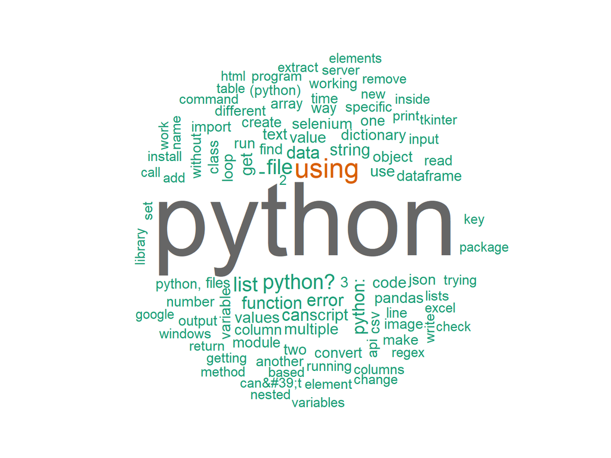

# Exploratory Data Analysis

**Questions asked over Years**

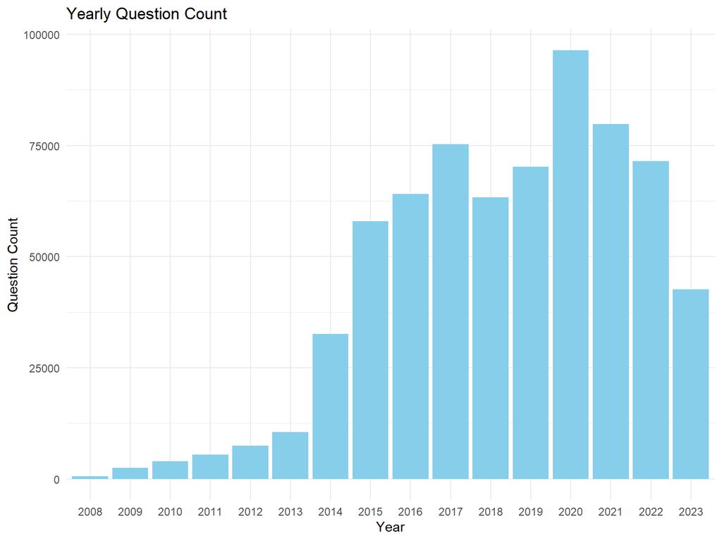

# Exploratory Data Analysis

**Tag growth/shrinking over time**

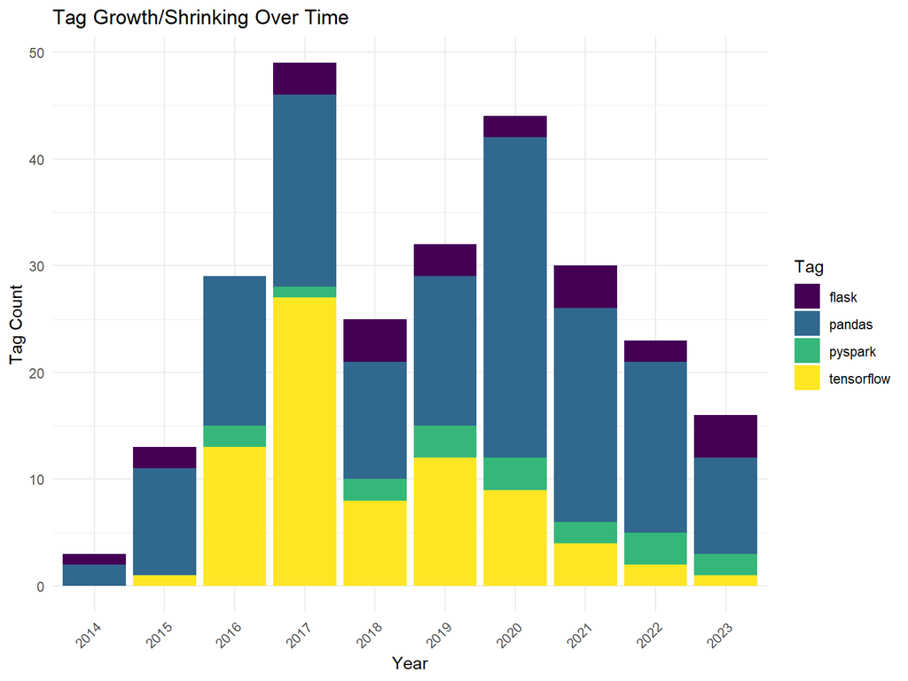

# Keras Word2Vec Model

Word2Vec is a tool that learns compact numerical representations (vectors) for words by analyzing how they are used together in a given set of text.

- Goal: Word2Vec is like a brain for computers that tries to understand words in a way that’s similar to how humans do.
- Representation: Instead of just knowing what a word is, Word2Vec wants to represent each word as a special kind of number. These numbers capture the essence of what each word means.
- How it Learns: Imagine teaching a computer to understand words by reading a lot of text. It looks at the words that often appear together and learns that they must be related.
- Two Jobs: Word2Vec has two main jobs or games to play: Guess the Word: Given the words around it, try to guess what the missing word is. This helps the computer learn the meaning of words based on context.
- Guess the Context: Given a word, try to guess what words are likely to appear around it. This helps the computer understand how words relate to each other.
- Vectors: Once trained, each word gets its special set of numbers (vector). Words with similar meanings have vectors that point in similar directions.

# Keras Word2Vec Results

**Question -> How to run python in conda environment ?**

```
##        run elevenlabs      pitch    layered       book       days   logstash
##  1.0000000  0.5737176  0.5550957  0.5288951  0.4849439  0.4794046  0.4791245
```

# Vector Representation

[output not shown]

[output cut: 2558 more lines]

[output not shown]

# Word Embedding

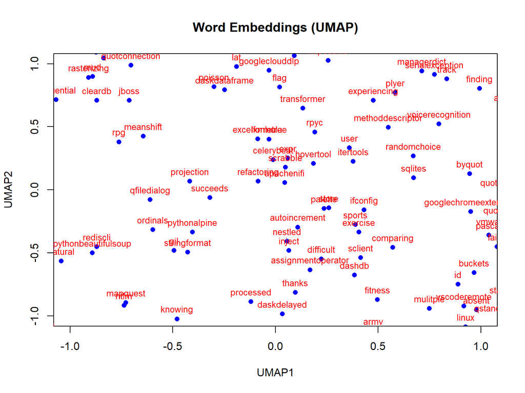

# Paragraph2vec Approach

- Contextual Understanding: Paragraph2Vec excels at capturing contextual information in variable-length Stack Overflow questions, providing a holistic view of the entire text.
- Document-Level Semantics: Tailored for understanding document-level semantics, Paragraph2Vec is well-suited for tasks that require comprehending the overall context and purpose of Stack Overflow questions.
- Efficient Retrieval and Similarity: Ideal for tasks like document retrieval and similarity, Paragraph2Vec embeddings facilitate efficient operations by reducing dimensionality while retaining semantic information.
- Handling Variable-Length Texts: As Stack Overflow questions vary in length, Paragraph2Vec’s ability to handle variable-length texts ensures robust performance in capturing meaningful relationships within questions.

# Paragraph2Vec Result

### Question -> How to run python in conda environment ?

**Similarity Matrix**

```
##          term1        term2 similarity rank
## 1        conda     anaconda  0.9151204    1
## 2        conda environement  0.8750440    4
## 3        conda    miniconda  0.8700238    5
## 4        conda    pippython  0.8859061    3
## 5        conda        pyopt  0.8862889    2
## 6  environment          env  0.9720023    1
## 7  environment   enviroment  0.9143285    3
## 8  environment      utility  0.8447001    5
## 9  environment         venv  0.8642362    4
## 10 environment      virtual  0.9175690    2
## 11      python    overwrite  0.8554232    3
## 12      python      passing  0.8754611    1
## 13      python     printing  0.8479622    5
## 14      python      pythonx  0.8709121    2
## 15      python      writing  0.8501320    4
## 16         run      execute  0.9763917    1
## 17         run    executing  0.9418076    2
## 18         run       launch  0.9300061    5
## 19         run      running  0.9352252    4
## 20         run         runs  0.9377644    3
```

**Related Tags**

```
##  [1] "execute"      "env"          "executing"    "runs"         "running"
##  [6] "launch"       "virtual"      "anaconda"     "enviroment"   "pyopt"
## [11] "pippython"    "passing"      "environement" "pythonx"      "miniconda"
## [16] "venv"         "overwrite"    "writing"
```

```
## [1] "execute"   "env"       "launch"    "virtual"   "anaconda"  "miniconda"
## [7] "overwrite"
```